# Modeling and prediction for movies

## Setup

### Load packages

```r
library(ggplot2)
library(dplyr)
library(statsr)
```

### Load data

To start with the analysis, the **movies.rdata** dataset is loaded to the environment.

```r
load("movies.rdata")
```

## Part 1: Data

The data to be analysed consists of information about 651 randomly sampled movies. The dataset includes information about the movie (title, genre, among others), release dates in theathers and DVD, [IMDB](http://www.imdb.com) and [Rotten Tomatos](https://www.rottentomatoes.com/) scores, and information about awards, main actors and actresses.

Regarding the scores, in IMDB users can rate films on a scale of 1 to 10, and the totals are converted into a weighted mean-rating that is displayed beside each title. It can be said that convenience sampling is used. (IMDB [Wikipedia page](https://en.wikipedia.org/wiki/IMDb))

Rotten Tomatoes, on the other hand, collects online reviews from writers who are certified film critics. Additionally, the audience can rate movies from 0 to 10. Purposive (expert) and convenience sampling are used for the critics and audience, respectively. (Rotten Tomatoes [Wikipedia page](https://en.wikipedia.org/wiki/Rotten_Tomatoes))

The use of random sampling suggests that the results can be used for generalization. Since the movies are a simple random sample, it can be argued, for example, that some genres might be less represented than others. Convenience samples are argued to be a source of bias, specially in case like ours, when the rating is based on subjective aspects. Therefore, we need to be cautions with the results of inference and prediction when analysing this dataset.

There was no random assignment for the collection of the rating data or the movie sampling, hence, the study cannot be used to suggest causation, regardless of the results of the methods used in the sections below.

## Part 2: Research question

Studies are always competing to have the most successful and influential movies. Paramount pictures has not exceeded the legacy of their ultimate iconic film Titanic from 1997 and we want to understand what variables can lead to an equal or even bigger success. Consequently, the interest of our boss is learning what attributes make a movie popular. For this analysis, we will use IMDB’s rating `imdb_rating` and Rotten Tomatoes’ audience scores `audience_score` as our measures of a film’s popularity (more on that below). The above mentioned movie is 195 minutes long, but the top 10 movies in Rotten Tomatoes are far shorter than that. We wonder if the length of a movie would influence on its popularity.

> If a movie is longer than 120 minutes, is that a significant predictor for its popularity expressed in terms of its Rotten Tomatos’ ratings?

## Part 3: Exploratory data analysis

### Preparing the dataset

The dataset provides 32 variables to play with. The current fields are the following:

```r
names(movies)
```

```
##  [1] "title"            "title_type"       "genre"
##  [4] "runtime"          "mpaa_rating"      "studio"
##  [7] "thtr_rel_year"    "thtr_rel_month"   "thtr_rel_day"
## [10] "dvd_rel_year"     "dvd_rel_month"    "dvd_rel_day"
## [13] "imdb_rating"      "imdb_num_votes"   "critics_rating"
## [16] "critics_score"    "audience_rating"  "audience_score"
## [19] "best_pic_nom"     "best_pic_win"     "best_actor_win"
## [22] "best_actress_win" "best_dir_win"     "top200_box"
## [25] "director"         "actor1"           "actor2"
## [28] "actor3"           "actor4"           "actor5"
## [31] "imdb_url"         "rt_url"
```

Even though our research question aims to detect if running_time is a good predictor, we choose different variables to have room for comparison.

First, we recode the `runtime` variable and make it categorical:

```r
movies$running_time <- cut(movies$runtime, breaks=c(-Inf, 40, 60, 90, 120, Inf),  labels=c("< 40 min","40-60 min","60-90 min","90-120 min",">120 min"))
```

Now, we merge the `best_actor_win` and `best_actress_win` variables in one:

```r
movies$casting_win <- ifelse(movies$best_actor_win == "yes", "Yes", ifelse(movies$best_actress_win == "yes", "Yes", "No"))
```

We change the numerical `thtr_rel_month` to a categorical variable

```r
movies$release_month <- month.abb[movies$thtr_rel_month]
```

We want our ratings to be expresed in the same scale. Therefore we transform `critics_score` and `audience_score`

```r
movies$rt_critics_score <- movies$critics_score/10
movies$rt_audience_score <- movies$audience_score/10
```

For this analysis, we can consider using IMDB’s rating `imdb_rating` and Rotten Tomatoes’ audience scores `audience_score` as our measures of a film’s popularity.

Let’s analise both variables:

```r
#IMDB ratings
summary(movies$imdb_rating)
```

```
##    Min. 1st Qu.  Median    Mean 3rd Qu.    Max.
##   1.900   5.900   6.600   6.493   7.300   9.000
```

```r
#Rotten Tomatoes audience score
summary(movies$rt_audience_score)
```

```
##    Min. 1st Qu.  Median    Mean 3rd Qu.    Max.
##   1.100   4.600   6.500   6.236   8.000   9.700
```

Our reduced dataset is now:

```r
movies_reduced <- subset(movies, select = c(rt_audience_score, rt_critics_score, genre, running_time, release_month, best_dir_win, casting_win))

names(movies_reduced)
```

```
## [1] "rt_audience_score" "rt_critics_score"  "genre"
## [4] "running_time"      "release_month"     "best_dir_win"
## [7] "casting_win"
```

```r
head(movies_reduced)
```

```
## Source: local data frame [6 x 7]
##
##   rt_audience_score rt_critics_score       genre running_time
##               <dbl>            <dbl>      <fctr>       <fctr>
## 1               7.3              4.5       Drama    60-90 min
## 2               8.1              9.6       Drama   90-120 min
## 3               9.1              9.1      Comedy    60-90 min
## 4               7.6              8.0       Drama     >120 min
## 5               2.7              3.3      Horror    60-90 min
## 6               8.6              9.1 Documentary    60-90 min
## Variables not shown: release_month <chr>, best_dir_win <fctr>, casting_win
##   <chr>.
```

### Summary statistics and data plots

Now, we plot the relationship between the variables, having `rt_audience_score` as response variable.

### `rt_critics_score`

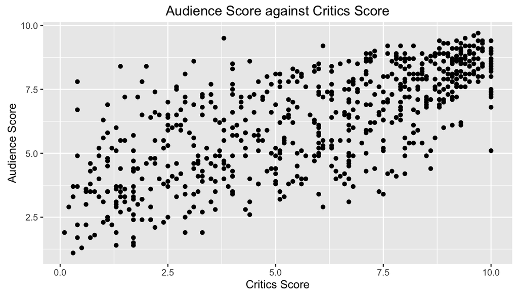

```r
ggplot(data=movies_reduced, aes(x = rt_critics_score, y = rt_audience_score)) + geom_point()+
   labs(title = "Audience Score against Critics Score", x = "Critics Score", y = "Audience Score")
```

```r
summary(movies_reduced$rt_critics_score)
```

```
##    Min. 1st Qu.  Median    Mean 3rd Qu.    Max.
##   0.100   3.300   6.100   5.769   8.300  10.000
```

We can see that there is a positive linear relationship between `critics_score` y `audience_score`. We keep the variable for the model.

### `genre`

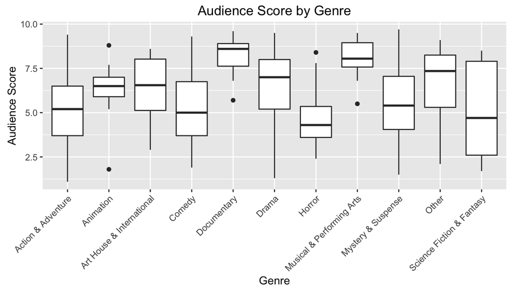

```r
ggplot(data = movies_reduced, aes(x=genre, y = rt_audience_score)) +
  geom_boxplot()+
  labs(title = "Audience Score by Genre", x = "Genre", y = "Audience Score")+
  theme(axis.text.x = element_text(angle = 45, hjust = 1))
```

```r
summary(movies_reduced$genre)
```

```
##        Action & Adventure                 Animation
##                        65                         9
## Art House & International                    Comedy
##                        14                        87
##               Documentary                     Drama
##                        52                       305
##                    Horror Musical & Performing Arts
##                        23                        12
##        Mystery & Suspense                     Other
##                        59                        16
## Science Fiction & Fantasy
##                         9
```

The plot shows a clear variation of scores between different genres for the movies in the sample. Documentaries and Musical & Performing Arts show higher punctuations. We can also keep this variable.

### `release_month`

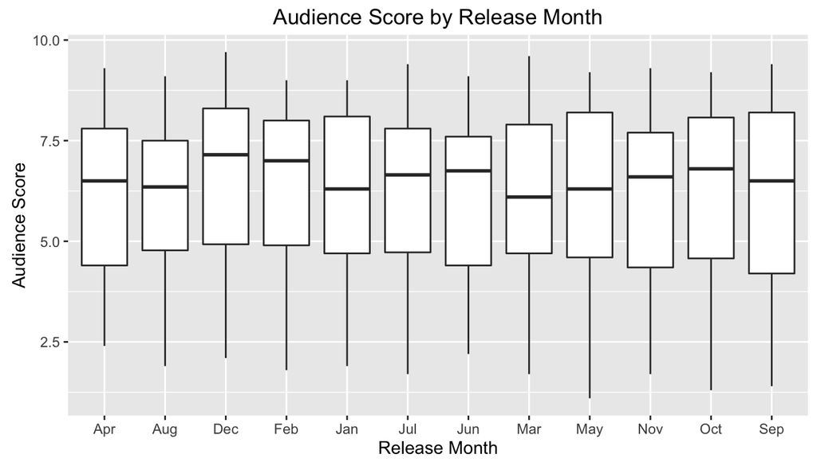

```r
ggplot(data=movies_reduced,aes(x = release_month, y = rt_audience_score)) +
  geom_boxplot() +
  labs(title = "Audience Score by Release Month", x = "Release Month", y = "Audience Score")
```

```r
summary(movies_reduced$release_month)
```

```
##    Length     Class      Mode
##       651 character character
```

The plot shows different medians for the months, but similar IQRs.

### `running_time`

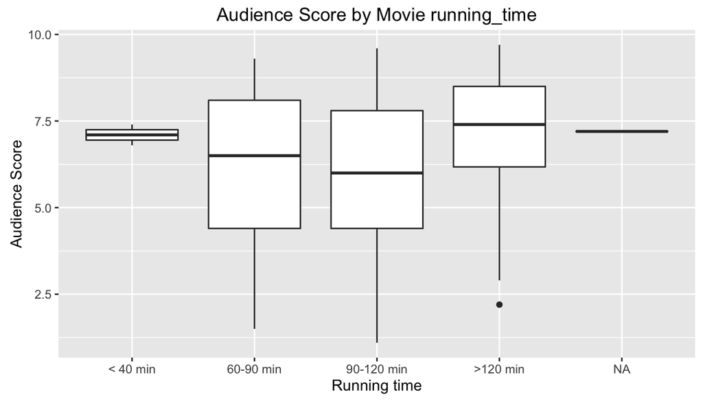

```r
ggplot(data=movies_reduced,aes(x = running_time, y = rt_audience_score)) +
  geom_boxplot() +
  labs(title = "Audience Score by Movie running_time", x = "Running time", y = "Audience Score")
```

```r
summary(movies_reduced$running_time)
```

```
##   < 40 min  40-60 min  60-90 min 90-120 min   >120 min       NA's
##          2          0        123        405        120          1
```

The plot shows a variation between movies with different lengths. We keep this variable as well.

### `best_dir_win`

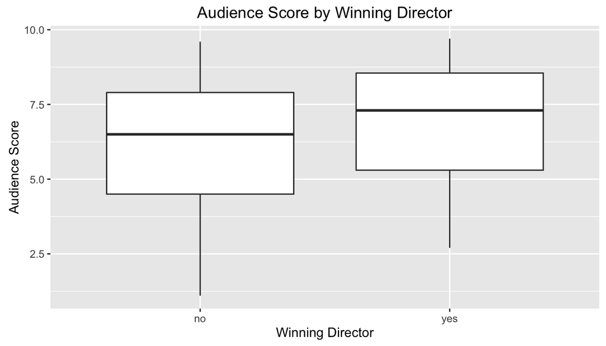

```r
ggplot(data=movies_reduced,aes(x = best_dir_win, y = rt_audience_score)) +
  geom_boxplot() +
  labs(title = "Audience Score by Winning Director", x = "Winning Director", y = "Audience Score")
```

```r
summary(movies_reduced$best_dir_win)
```

```
##  no yes
## 608  43
```

According to the plot, movies with Oscar award winning directors appear to score higher. This variable is kept too.

### `casting_win`

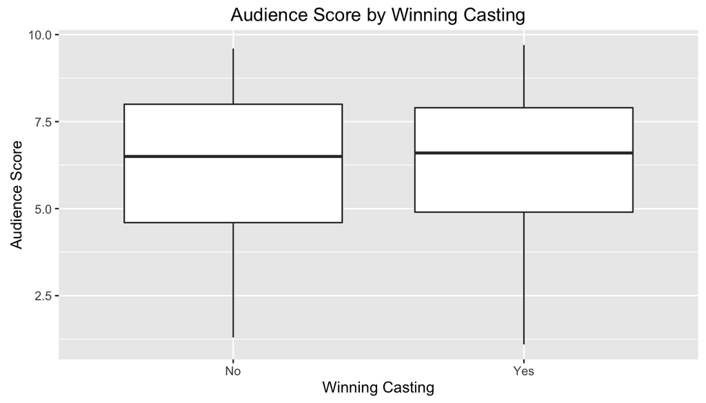

```r
ggplot(data=movies_reduced,aes(x = casting_win, y = rt_audience_score)) +
  geom_boxplot() +
  labs(title = "Audience Score by Winning Casting", x = "Winning Casting", y = "Audience Score")
```

```r
summary(movies_reduced$casting_win)
```

```
##    Length     Class      Mode
##       651 character character
```

It does not appear to be a major difference in scores between movies with and without Oscar winning casting. We decide to leave this variable outside our model.

The dataset for our model is now the following:

```r
movies_full <- subset(movies_reduced, select = c(rt_audience_score, rt_critics_score, genre, running_time, release_month, best_dir_win))

#Cleaning up the working space
rm(movies)
rm(movies_reduced)
```

## Part 4: Modeling

Since the investment that is needed to make a movie is really high, we are interested in more reliable predictors over statiscally significant ones. Therefore, we choose backwards ellimination with $R^2$ instead of p-value method.

We start with a full model considering the variables:

- **Explanatory variables:** `rt_critics_score`, `genre`, `running_time`, `release_month`, `best_dir_win`
- **Response variable:** `rt_audience_score`

```r
model_full <- lm(rt_audience_score ~ rt_critics_score + genre + running_time + release_month + best_dir_win, data = movies_full)
summary(model_full)
```

```
##
## Call:
## lm(formula = rt_audience_score ~ rt_critics_score + genre + running_time +
##     release_month + best_dir_win, data = movies_full)
##
## Residuals:
##     Min      1Q  Median      3Q     Max
## -3.7480 -0.9334  0.0616  0.9403  4.3744
##
## Coefficients:
##                                Estimate Std. Error t value Pr(>|t|)
## (Intercept)                     1.74381    1.03791   1.680  0.09344 .
## rt_critics_score                0.45257    0.02200  20.568  < 2e-16 ***
## genreAnimation                  0.36966    0.50984   0.725  0.46869
## genreArt House & International  0.56552    0.41291   1.370  0.17131
## genreComedy                    -0.08683    0.23007  -0.377  0.70601
## genreDocumentary                0.88224    0.28862   3.057  0.00233 **
## genreDrama                      0.14469    0.19897   0.727  0.46739
## genreHorror                    -0.89596    0.34298  -2.612  0.00921 **
## genreMusical & Performing Arts  0.88235    0.44943   1.963  0.05006 .
## genreMystery & Suspense        -0.45600    0.25660  -1.777  0.07604 .
## genreOther                      0.13910    0.39696   0.350  0.72614
## genreScience Fiction & Fantasy -0.68593    0.50091  -1.369  0.17138
## running_time60-90 min           1.91069    1.01882   1.875  0.06121 .
## running_time90-120 min          1.69976    1.01797   1.670  0.09547 .
## running_time>120 min            2.27432    1.02601   2.217  0.02701 *
## release_monthAug               -0.10121    0.29792  -0.340  0.73419
## release_monthDec                0.06508    0.27222   0.239  0.81113
## release_monthFeb                0.13502    0.32045   0.421  0.67365
## release_monthJan                0.03514    0.27056   0.130  0.89669
## release_monthJul                0.07609    0.29185   0.261  0.79440
## release_monthJun               -0.10242    0.26859  -0.381  0.70310
## release_monthMar               -0.08964    0.28843  -0.311  0.75607
## release_monthMay               -0.18616    0.29994  -0.621  0.53505
## release_monthNov               -0.09202    0.29188  -0.315  0.75267
## release_monthOct               -0.10345    0.26939  -0.384  0.70110
## release_monthSep               -0.05159    0.28636  -0.180  0.85710
## best_dir_winyes                -0.02841    0.23138  -0.123  0.90232
## ---
## Signif. codes:  0 '***' 0.001 '**' 0.01 '*' 0.05 '.' 0.1 ' ' 1
##
## Residual standard error: 1.396 on 623 degrees of freedom
##   (1 observation deleted due to missingness)
## Multiple R-squared:  0.5432, Adjusted R-squared:  0.5242
## F-statistic:  28.5 on 26 and 623 DF,  p-value: < 2.2e-16
```

| variables included | removed | adjusted $R^2$ |
| --- | --- | --- |
| `rt_audience_score ~ rt_critics_score + genre + running_time + release_month + best_dir_win` |  | **0.5242** |

### STEP 1

We start removing variables one by one to see which change yields the higher $R^2$.

First, we remove `rt_critics_score`

```r
model_1 <- lm(rt_audience_score ~ genre + running_time + release_month + best_dir_win, data = movies_full)
summary(model_1)
```

```
##
## Call:
## lm(formula = rt_audience_score ~ genre + running_time + release_month +
##     best_dir_win, data = movies_full)
##
## Residuals:
##     Min      1Q  Median      3Q     Max
## -4.9160 -1.2597  0.1228  1.3432  4.2449
##
## Coefficients:
##                                 Estimate Std. Error t value Pr(>|t|)
## (Intercept)                     4.138978   1.335342   3.100  0.00203 **
## genreAnimation                  0.913652   0.659217   1.386  0.16625
## genreArt House & International  1.107224   0.533521   2.075  0.03837 *
## genreComedy                    -0.074096   0.297886  -0.249  0.80364
## genreDocumentary                3.006227   0.348943   8.615  < 2e-16 ***
## genreDrama                      1.045908   0.251295   4.162 3.60e-05 ***
## genreHorror                    -0.730490   0.443948  -1.645  0.10038
## genreMusical & Performing Arts  2.373040   0.574280   4.132 4.08e-05 ***
## genreMystery & Suspense         0.097302   0.330401   0.294  0.76848
## genreOther                      1.082411   0.510516   2.120  0.03438 *
## genreScience Fiction & Fantasy -0.274170   0.648026  -0.423  0.67238
## running_time60-90 min           1.234996   1.318429   0.937  0.34927
## running_time90-120 min          1.121558   1.317504   0.851  0.39494
## running_time>120 min            1.911710   1.328224   1.439  0.15057
## release_monthAug               -0.104025   0.385729  -0.270  0.78749
## release_monthDec                0.221795   0.352320   0.630  0.52923
## release_monthFeb                0.064355   0.414882   0.155  0.87678
## release_monthJan                0.037565   0.350304   0.107  0.91464
## release_monthJul                0.009432   0.377843   0.025  0.98009
## release_monthJun                0.093233   0.347542   0.268  0.78859
## release_monthMar               -0.337943   0.373114  -0.906  0.36543
## release_monthMay                0.035236   0.388096   0.091  0.92769
## release_monthNov               -0.219395   0.377825  -0.581  0.56167
## release_monthOct               -0.090410   0.348788  -0.259  0.79556
## release_monthSep               -0.202762   0.370637  -0.547  0.58453
## best_dir_winyes                 0.600547   0.296954   2.022  0.04357 *
## ---
## Signif. codes:  0 '***' 0.001 '**' 0.01 '*' 0.05 '.' 0.1 ' ' 1
##
## Residual standard error: 1.807 on 624 degrees of freedom
##   (1 observation deleted due to missingness)
## Multiple R-squared:  0.233,  Adjusted R-squared:  0.2023
## F-statistic: 7.584 on 25 and 624 DF,  p-value: < 2.2e-16
```

| variables included | removed | adjusted $R^2$ |
| --- | --- | --- |
| `rt_audience_score ~ rt_critics_score + genre + running_time + release_month + best_dir_win` |  | **0.5242** |
| `rt_audience_score ~ genre + running_time + release_month + best_dir_win` | `rt_critics_score` | 0.2023 |

We got a $R^2$ of 0.2023. That means that we should keep `rt_critics_score` in our model.

Now we remove `genre`

```r
model_1 <- lm(rt_audience_score ~ rt_critics_score + running_time + release_month + best_dir_win, data = movies_full)
summary(model_1)
```

```
##
## Call:
## lm(formula = rt_audience_score ~ rt_critics_score + running_time +
##     release_month + best_dir_win, data = movies_full)
##
## Residuals:
##     Min      1Q  Median      3Q     Max
## -3.6390 -0.9366  0.0724  0.9802  4.4449
##
## Coefficients:
##                         Estimate Std. Error t value Pr(>|t|)
## (Intercept)             2.223541   1.039969   2.138   0.0329 *
## rt_critics_score        0.495107   0.020266  24.430   <2e-16 ***
## running_time60-90 min   1.311681   1.031803   1.271   0.2041
## running_time90-120 min  1.029589   1.025384   1.004   0.3157
## running_time>120 min    1.631366   1.031949   1.581   0.1144
## release_monthAug       -0.088938   0.304162  -0.292   0.7701
## release_monthDec        0.136943   0.277565   0.493   0.6219
## release_monthFeb        0.203599   0.326160   0.624   0.5327
## release_monthJan        0.019338   0.275423   0.070   0.9440
## release_monthJul        0.096117   0.297961   0.323   0.7471
## release_monthJun       -0.170933   0.273091  -0.626   0.5316
## release_monthMar        0.004733   0.294193   0.016   0.9872
## release_monthMay       -0.188678   0.305767  -0.617   0.5374
## release_monthNov       -0.067521   0.296728  -0.228   0.8201
## release_monthOct       -0.149215   0.275225  -0.542   0.5879
## release_monthSep        0.008810   0.291965   0.030   0.9759
## best_dir_winyes        -0.165137   0.235552  -0.701   0.4835
## ---
## Signif. codes:  0 '***' 0.001 '**' 0.01 '*' 0.05 '.' 0.1 ' ' 1
##
## Residual standard error: 1.43 on 633 degrees of freedom
##   (1 observation deleted due to missingness)
## Multiple R-squared:  0.513,  Adjusted R-squared:  0.5007
## F-statistic: 41.68 on 16 and 633 DF,  p-value: < 2.2e-16
```

| variables included | removed | adjusted $R^2$ |
| --- | --- | --- |
| `rt_audience_score ~ rt_critics_score + genre + running_time + release_month + best_dir_win` |  | **0.5242** |
| `rt_audience_score ~ genre + running_time + release_month + best_dir_win` | `rt_critics_score` | 0.2023 |
| `rt_audience_score ~ rt_critics_score + running_time + release_month + best_dir_win` | `genre` | 0.5007 |

We got a $R^2$ of 0.5007. That means that we should keep `genre` in our model.

Now we remove `running_time`

```r
model_1 <- lm(rt_audience_score ~ rt_critics_score + genre + release_month + best_dir_win, data = movies_full)
summary(model_1)
```

```
##
## Call:
## lm(formula = rt_audience_score ~ rt_critics_score + genre + release_month +
##     best_dir_win, data = movies_full)
##
## Residuals:
##     Min      1Q  Median      3Q     Max
## -3.7059 -0.9305  0.0561  0.9521  4.2940
##
## Coefficients:
##                                Estimate Std. Error t value Pr(>|t|)
## (Intercept)                     3.41949    0.28513  11.993  < 2e-16 ***
## rt_critics_score                0.45627    0.02217  20.583  < 2e-16 ***
## genreAnimation                  0.39104    0.51015   0.767  0.44365
## genreArt House & International  0.57747    0.41735   1.384  0.16696
## genreComedy                    -0.09255    0.23231  -0.398  0.69047
## genreDocumentary                0.86268    0.28476   3.029  0.00255 **
## genreDrama                      0.20215    0.19956   1.013  0.31146
## genreHorror                    -0.89233    0.34517  -2.585  0.00996 **
## genreMusical & Performing Arts  1.01233    0.45261   2.237  0.02566 *
## genreMystery & Suspense        -0.38274    0.25788  -1.484  0.13826
## genreOther                      0.21319    0.40087   0.532  0.59503
## genreScience Fiction & Fantasy -0.67203    0.50613  -1.328  0.18474
## release_monthAug               -0.02969    0.30009  -0.099  0.92123
## release_monthDec                0.21492    0.27167   0.791  0.42917
## release_monthFeb                0.20789    0.32299   0.644  0.52005
## release_monthJan                0.10966    0.27238   0.403  0.68739
## release_monthJul                0.17546    0.29379   0.597  0.55058
## release_monthJun               -0.01485    0.27037  -0.055  0.95620
## release_monthMar               -0.01166    0.29045  -0.040  0.96799
## release_monthMay               -0.06547    0.30164  -0.217  0.82825
## release_monthNov                0.10881    0.29087   0.374  0.70846
## release_monthOct               -0.02978    0.27059  -0.110  0.91239
## release_monthSep                0.04773    0.28805   0.166  0.86845
## best_dir_winyes                 0.12708    0.22965   0.553  0.58022
## ---
## Signif. codes:  0 '***' 0.001 '**' 0.01 '*' 0.05 '.' 0.1 ' ' 1
##
## Residual standard error: 1.411 on 627 degrees of freedom
## Multiple R-squared:  0.5302, Adjusted R-squared:  0.513
## F-statistic: 30.77 on 23 and 627 DF,  p-value: < 2.2e-16
```

| variables included | removed | adjusted $R^2$ |
| --- | --- | --- |
| `rt_audience_score ~ rt_critics_score + genre + running_time + release_month + best_dir_win` |  | **0.5242** |
| `rt_audience_score ~ genre + running_time + release_month + best_dir_win` | `rt_critics_score` | 0.2023 |
| `rt_audience_score ~ rt_critics_score + running_time + release_month + best_dir_win` | `genre` | 0.5007 |
| `rt_audience_score ~ rt_critics_score + genre + release_month + best_dir_win` | `running_time` | 0.513 |

We got a $R^2$ of 0.513. That means that we should keep `running_time` in our model.

Now we remove `release_month`

```r
model_1 <- lm(rt_audience_score ~ rt_critics_score + genre + running_time + best_dir_win, data = movies_full)
summary(model_1)
```

```
##
## Call:
## lm(formula = rt_audience_score ~ rt_critics_score + genre + running_time +
##     best_dir_win, data = movies_full)
##
## Residuals:
##     Min      1Q  Median      3Q     Max
## -3.8205 -0.9059  0.0612  0.9555  4.3564
##
## Coefficients:
##                                Estimate Std. Error t value Pr(>|t|)
## (Intercept)                     1.68579    1.02248   1.649  0.09970 .
## rt_critics_score                0.45207    0.02170  20.833  < 2e-16 ***
## genreAnimation                  0.42939    0.49831   0.862  0.38918
## genreArt House & International  0.55658    0.40957   1.359  0.17465
## genreComedy                    -0.09312    0.22761  -0.409  0.68259
## genreDocumentary                0.89356    0.28399   3.146  0.00173 **
## genreDrama                      0.14739    0.19608   0.752  0.45250
## genreHorror                    -0.90185    0.33813  -2.667  0.00784 **
## genreMusical & Performing Arts  0.88749    0.44413   1.998  0.04611 *
## genreMystery & Suspense        -0.46259    0.25208  -1.835  0.06696 .
## genreOther                      0.14626    0.39070   0.374  0.70826
## genreScience Fiction & Fantasy -0.71050    0.49386  -1.439  0.15074
## running_time60-90 min           1.92587    1.00360   1.919  0.05544 .
## running_time90-120 min          1.72495    1.00358   1.719  0.08614 .
## running_time>120 min            2.29450    1.01049   2.271  0.02350 *
## best_dir_winyes                -0.01737    0.22765  -0.076  0.93920
## ---
## Signif. codes:  0 '***' 0.001 '**' 0.01 '*' 0.05 '.' 0.1 ' ' 1
##
## Residual standard error: 1.386 on 634 degrees of freedom
##   (1 observation deleted due to missingness)
## Multiple R-squared:  0.5414, Adjusted R-squared:  0.5306
## F-statistic:  49.9 on 15 and 634 DF,  p-value: < 2.2e-16
```

| variables included | removed | adjusted $R^2$ |
| --- | --- | --- |
| `rt_audience_score ~ rt_critics_score + genre + running_time + release_month + best_dir_win` |  | **0.5242** |
| `rt_audience_score ~ genre + running_time + release_month + best_dir_win` | `rt_critics_score` | 0.2023 |
| `rt_audience_score ~ rt_critics_score + running_time + release_month + best_dir_win` | `genre` | 0.5007 |
| `rt_audience_score ~ rt_critics_score + genre + release_month + best_dir_win` | `running_time` | 0.513 |
| `rt_audience_score ~ rt_critics_score + genre + running_time + best_dir_win` | `release_month` | **0.5306** |

We got a $R^2$ of 0.5306, which is higher than our original model. That means that we might drop `release_month` from our model.

Finally we remove `best_dir_win`

```r
model_1 <- lm(rt_audience_score ~ rt_critics_score + genre + running_time + release_month, data = movies_full)
summary(model_1)
```

```
##
## Call:
## lm(formula = rt_audience_score ~ rt_critics_score + genre + running_time +
##     release_month, data = movies_full)
##
## Residuals:
##     Min      1Q  Median      3Q     Max
## -3.7700 -0.9314  0.0631  0.9430  4.3734
##
## Coefficients:
##                                Estimate Std. Error t value Pr(>|t|)
## (Intercept)                     1.74417    1.03709   1.682  0.09311 .
## rt_critics_score                0.45221    0.02179  20.750  < 2e-16 ***
## genreAnimation                  0.37116    0.50929   0.729  0.46640
## genreArt House & International  0.56746    0.41228   1.376  0.16919
## genreComedy                    -0.08665    0.22989  -0.377  0.70637
## genreDocumentary                0.88525    0.28734   3.081  0.00216 **
## genreDrama                      0.14538    0.19874   0.732  0.46474
## genreHorror                    -0.89568    0.34270  -2.614  0.00918 **
## genreMusical & Performing Arts  0.88387    0.44890   1.969  0.04940 *
## genreMystery & Suspense        -0.45609    0.25640  -1.779  0.07575 .
## genreOther                      0.14021    0.39654   0.354  0.72378
## genreScience Fiction & Fantasy -0.68725    0.50040  -1.373  0.17012
## running_time60-90 min           1.90960    1.01798   1.876  0.06114 .
## running_time90-120 min          1.69834    1.01710   1.670  0.09546 .
## running_time>120 min            2.26936    1.02441   2.215  0.02710 *
## release_monthAug               -0.10102    0.29768  -0.339  0.73445
## release_monthDec                0.06562    0.27197   0.241  0.80941
## release_monthFeb                0.13680    0.31987   0.428  0.66904
## release_monthJan                0.03667    0.27006   0.136  0.89203
## release_monthJul                0.07658    0.29159   0.263  0.79293
## release_monthJun               -0.10199    0.26836  -0.380  0.70403
## release_monthMar               -0.08758    0.28771  -0.304  0.76093
## release_monthMay               -0.18306    0.29863  -0.613  0.54012
## release_monthNov               -0.09068    0.29145  -0.311  0.75580
## release_monthOct               -0.10306    0.26916  -0.383  0.70193
## release_monthSep               -0.04898    0.28535  -0.172  0.86376
## ---
## Signif. codes:  0 '***' 0.001 '**' 0.01 '*' 0.05 '.' 0.1 ' ' 1
##
## Residual standard error: 1.395 on 624 degrees of freedom
##   (1 observation deleted due to missingness)
## Multiple R-squared:  0.5432, Adjusted R-squared:  0.5249
## F-statistic: 29.68 on 25 and 624 DF,  p-value: < 2.2e-16
```

| variables included | removed | adjusted $R^2$ |
| --- | --- | --- |
| `rt_audience_score ~ rt_critics_score + genre + running_time + release_month + best_dir_win` |  | **0.5242** |
| `rt_audience_score ~ genre + running_time + release_month + best_dir_win` | `rt_critics_score` | 0.2023 |
| `rt_audience_score ~ rt_critics_score + running_time + release_month + best_dir_win` | `genre` | 0.5007 |
| `rt_audience_score ~ rt_critics_score + genre + release_month + best_dir_win` | `running_time` | 0.513 |
| `rt_audience_score ~ rt_critics_score + genre + running_time + best_dir_win` | `release_month` | **0.5306** |
| `rt_audience_score ~ rt_critics_score + genre + running_time + release_month` | `best_dir_win` | **0.5249** |

We got a $R^2$ of 0.5249, which is higher than our original model.

Considering that both `best_dir_win` and `release_month` yield higher $R^2$, we can remove them from our model.

### STEP 2

For our next step, we start removing both `best_dir_win` and `release_month`

```r
model_2 <- lm(rt_audience_score ~ rt_critics_score + genre + running_time, data = movies_full)
summary(model_2)
```

```
##
## Call:
## lm(formula = rt_audience_score ~ rt_critics_score + genre + running_time,
##     data = movies_full)
##
## Residuals:
##     Min      1Q  Median      3Q     Max
## -3.8343 -0.9050  0.0607  0.9555  4.3567
##
## Coefficients:
##                                Estimate Std. Error t value Pr(>|t|)
## (Intercept)                     1.68606    1.02167   1.650   0.0994 .
## rt_critics_score                0.45184    0.02147  21.042   <2e-16 ***
## genreAnimation                  0.43032    0.49777   0.864   0.3876
## genreArt House & International  0.55781    0.40893   1.364   0.1730
## genreComedy                    -0.09298    0.22742  -0.409   0.6828
## genreDocumentary                0.89559    0.28252   3.170   0.0016 **
## genreDrama                      0.14792    0.19580   0.755   0.4503
## genreHorror                    -0.90175    0.33786  -2.669   0.0078 **
## genreMusical & Performing Arts  0.88867    0.44351   2.004   0.0455 *
## genreMystery & Suspense        -0.46258    0.25188  -1.837   0.0667 .
## genreOther                      0.14714    0.39022   0.377   0.7063
## genreScience Fiction & Fantasy -0.71116    0.49340  -1.441   0.1500
## running_time60-90 min           1.92593    1.00281   1.921   0.0552 .
## running_time90-120 min          1.72470    1.00279   1.720   0.0859 .
## running_time>120 min            2.29206    1.00920   2.271   0.0235 *
## ---
## Signif. codes:  0 '***' 0.001 '**' 0.01 '*' 0.05 '.' 0.1 ' ' 1
##
## Residual standard error: 1.385 on 635 degrees of freedom
##   (1 observation deleted due to missingness)
## Multiple R-squared:  0.5414, Adjusted R-squared:  0.5313
## F-statistic: 53.55 on 14 and 635 DF,  p-value: < 2.2e-16
```

| variables included | removed | adjusted $R^2$ |
| --- | --- | --- |
| `rt_audience_score ~ rt_critics_score + genre + running_time` | `best_dir_win`, `release_month` | **0.5313** |

Now, we look for a $R^2$ higher than **0.5313**.

Let’s remove `running_time`

```r
model_2 <- lm(rt_audience_score ~ rt_critics_score + genre, data = movies_full)
summary(model_2)
```

```
##
## Call:
## lm(formula = rt_audience_score ~ rt_critics_score + genre, data = movies_full)
##
## Residuals:
##     Min      1Q  Median      3Q     Max
## -3.6538 -0.9667  0.0518  0.9525  4.2786
##
## Coefficients:
##                                Estimate Std. Error t value Pr(>|t|)
## (Intercept)                     3.47979    0.19547  17.803  < 2e-16 ***
## rt_critics_score                0.45828    0.02157  21.248  < 2e-16 ***
## genreAnimation                  0.46309    0.49885   0.928  0.35359
## genreArt House & International  0.55354    0.41355   1.339  0.18120
## genreComedy                    -0.10446    0.22979  -0.455  0.64956
## genreDocumentary                0.83818    0.27818   3.013  0.00269 **
## genreDrama                      0.20359    0.19665   1.035  0.30094
## genreHorror                    -0.91160    0.34009  -2.680  0.00754 **
## genreMusical & Performing Arts  1.02343    0.44688   2.290  0.02234 *
## genreMystery & Suspense        -0.40228    0.25370  -1.586  0.11331
## genreOther                      0.21590    0.39440   0.547  0.58429
## genreScience Fiction & Fantasy -0.68228    0.49883  -1.368  0.17187
## ---
## Signif. codes:  0 '***' 0.001 '**' 0.01 '*' 0.05 '.' 0.1 ' ' 1
##
## Residual standard error: 1.402 on 639 degrees of freedom
## Multiple R-squared:  0.5278, Adjusted R-squared:  0.5197
## F-statistic: 64.93 on 11 and 639 DF,  p-value: < 2.2e-16
```

| variables included | removed | adjusted $R^2$ |
| --- | --- | --- |
| `rt_audience_score ~ rt_critics_score + genre + running_time` | `best_dir_win`, `release_month` | **0.5313** |
| `rt_audience_score ~ rt_critics_score + genre` | `best_dir_win`, `release_month`, `running_time` | 0.5197 |

We keep `running_time` in the model.

Let’s remove `genre`

```r
model_2 <- lm(rt_audience_score ~ rt_critics_score + running_time, data = movies_full)
summary(model_2)
```

```
##
## Call:
## lm(formula = rt_audience_score ~ rt_critics_score + running_time,
##     data = movies_full)
##
## Residuals:
##     Min      1Q  Median      3Q     Max
## -3.9251 -0.9396  0.0460  0.9788  4.4747
##
## Coefficients:
##                        Estimate Std. Error t value Pr(>|t|)
## (Intercept)             2.16809    1.02489   2.115   0.0348 *
## rt_critics_score        0.49319    0.01995  24.719   <2e-16 ***
## running_time60-90 min   1.34343    1.01747   1.320   0.1872
## running_time90-120 min  1.06676    1.01163   1.054   0.2921
## running_time>120 min    1.64858    1.01580   1.623   0.1051
## ---
## Signif. codes:  0 '***' 0.001 '**' 0.01 '*' 0.05 '.' 0.1 ' ' 1
##
## Residual standard error: 1.422 on 645 degrees of freedom
##   (1 observation deleted due to missingness)
## Multiple R-squared:  0.5094, Adjusted R-squared:  0.5064
## F-statistic: 167.4 on 4 and 645 DF,  p-value: < 2.2e-16
```

| variables included | removed | adjusted $R^2$ |
| --- | --- | --- |
| `rt_audience_score ~ rt_critics_score + genre + running_time` | `best_dir_win`, `release_month` | **0.5313** |
| `rt_audience_score ~ rt_critics_score + genre` | `best_dir_win`, `release_month`, `running_time` | 0.5197 |
| `rt_audience_score ~ rt_critics_score + running_time` | `best_dir_win`, `release_month`, `genre` | 0.5064 |

We keep `genre` in the model as well.

Finally, let’s remove `rt_critics_score`

```r
model_2 <- lm(rt_audience_score ~ genre + running_time, data = movies_full)
summary(model_2)
```

```
##
## Call:
## lm(formula = rt_audience_score ~ genre + running_time, data = movies_full)
##
## Residuals:
##     Min      1Q  Median      3Q     Max
## -4.9986 -1.2629  0.1025  1.3175  4.1135
##
## Coefficients:
##                                Estimate Std. Error t value Pr(>|t|)
## (Intercept)                     4.16459    1.32112   3.152   0.0017 **
## genreAnimation                  0.91070    0.64730   1.407   0.1599
## genreArt House & International  1.03425    0.53152   1.946   0.0521 .
## genreComedy                    -0.09281    0.29605  -0.314   0.7540
## genreDocumentary                2.93541    0.34546   8.497  < 2e-16 ***
## genreDrama                      1.01929    0.24913   4.091 4.84e-05 ***
## genreHorror                    -0.73218    0.43970  -1.665   0.0964 .
## genreMusical & Performing Arts  2.36227    0.57011   4.144 3.88e-05 ***
## genreMystery & Suspense         0.08260    0.32615   0.253   0.8001
## genreOther                      1.15317    0.50415   2.287   0.0225 *
## genreScience Fiction & Fantasy -0.31583    0.64183  -0.492   0.6228
## running_time60-90 min           1.19639    1.30466   0.917   0.3595
## running_time90-120 min          1.11467    1.30486   0.854   0.3933
## running_time>120 min            1.99865    1.31362   1.521   0.1286
## ---
## Signif. codes:  0 '***' 0.001 '**' 0.01 '*' 0.05 '.' 0.1 ' ' 1
##
## Residual standard error: 1.803 on 636 degrees of freedom
##   (1 observation deleted due to missingness)
## Multiple R-squared:  0.2216, Adjusted R-squared:  0.2057
## F-statistic: 13.93 on 13 and 636 DF,  p-value: < 2.2e-16
```

| variables included | removed | adjusted $R^2$ |
| --- | --- | --- |
| `rt_audience_score ~ rt_critics_score + genre + running_time` | `best_dir_win, release_month` | **0.5313** |
| `rt_audience_score ~ rt_critics_score + genre` | `best_dir_win, release_month, running_time` | 0.5197 |
| `rt_audience_score ~ rt_critics_score + running_time` | `best_dir_win, release_month, genre` | 0.5064 |
| `rt_audience_score ~ genre + running_time` | `best_dir_win, release_month, rt_critics_score`, | 0.2057 |

Since none of the $R^2$ values are higher than **0.5313**, our final model to predict `rt_audience_score` will use `rt_critics_score`, `genre` and `running_time` as predictors.

```r
model_final <- lm(rt_audience_score ~ rt_critics_score + genre + running_time, data = movies_full)
```

### Model diagnostics

1. Linear relationships between numerical x and y

As seen in the EDA, there seems to exist a linear relationship between `rt_critics_score` y `rt_audience_score`. Now we confirm with the Residuals plot.

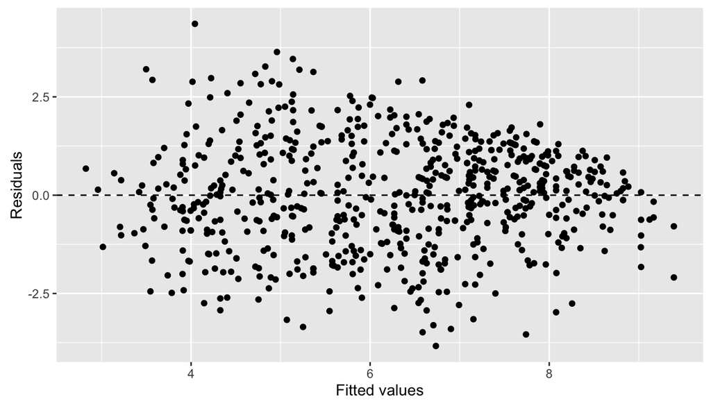

```r
ggplot(data = model_final, aes(x = .fitted, y = .resid)) +
  geom_point() +
  geom_hline(yintercept = 0, linetype = "dashed") +
  xlab("Fitted values") +
  ylab("Residuals")
```

The condition of random scatter around 0 is met.

2. Nearly normal resituals with mean 0

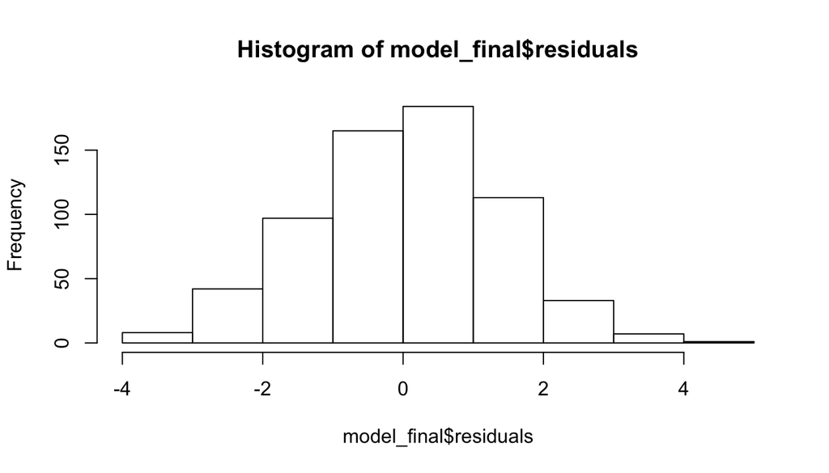

```r
hist(model_final$residuals)
```

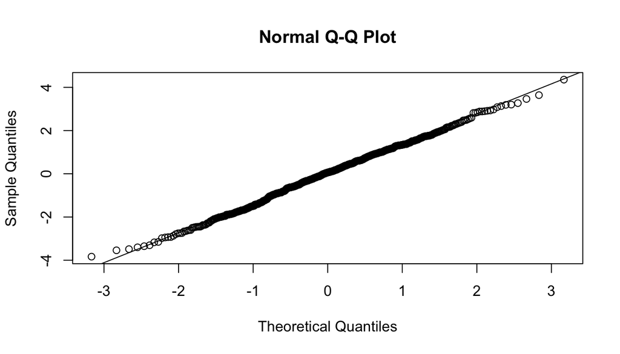

```r
qqnorm(model_final$residuals)
qqline(model_final$residuals)
```

The plot is indeed nearly normal around 0.

3. Constant variability of residuals

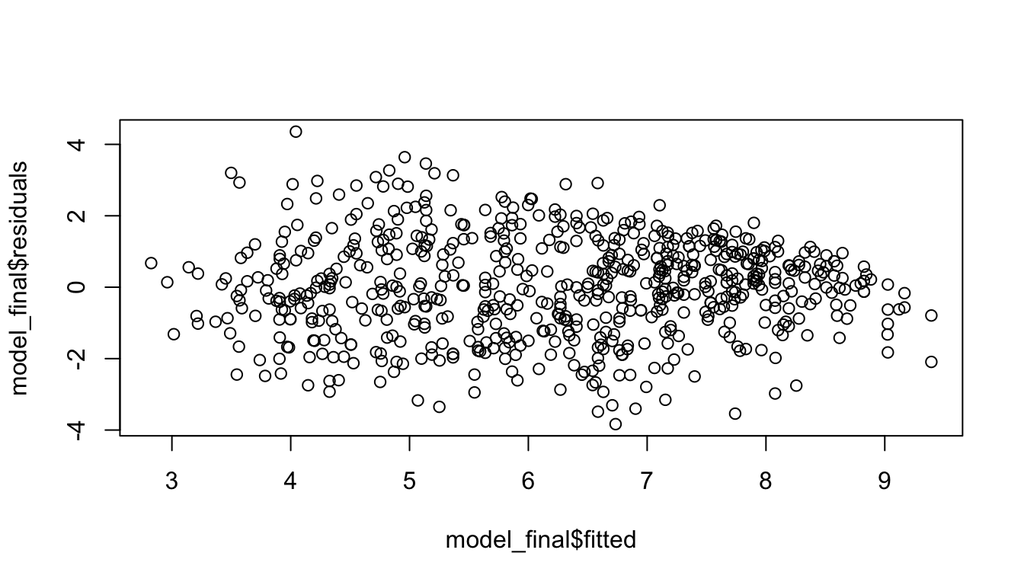

```r
plot(model_final$residuals ~ model_final$fitted)
```

The condition of constant variability is met.

## Part 5: Prediction

The movies chosen for this part of the study are [Now you see me 2](https://www.rottentomatoes.com/m/now_you_see_me_2/) and [Jason Bourne](http://www.imdb.com/title/tt4196776/?ref_=inth_ov_tt). We predict the scores with a prediction interval of 90%.

First we analyse **Now you see me 2**

```r
new_movie_1 <- data.frame(rt_critics_score =3.4, genre = "Mystery & Suspense", running_time="90-120 min")

predict(model_final, new_movie_1, interval = "prediction", level = 0.90)
```

```
##        fit     lwr      upr
## 1 4.484417 2.18112 6.787714
```

Now, we analyse **Jason Bourne**

```r
new_movie_2 <- data.frame(rt_critics_score =5.6, genre = "Action & Adventure", running_time=">120 min")

predict(model_final, new_movie_2, interval = "prediction", level = 0.90)
```

```
##        fit      lwr      upr
## 1 6.508398 4.198557 8.818238
```

## Part 6: Conclusion

| variables included | removed | adjusted $R^2$ |
| --- | --- | --- |
| `rt_audience_score ~ rt_critics_score + genre + running_time` | `best_dir_win, release_month` | **0.5313** |

We checked the conditions for model diagnostic and confirmed with plots that we met them all.

The model can still be refined by using some variables that were left behind and a bigger data sample.